# Case Study 2

Luke Stodgel

12/4/2021

# Github: https://github.com/lukestodgel/DDSProject2

# Youtube: https://youtu.be/HW_8mqiiL2I

#Summary of the Project #Our goal was to perform an EDA, find the top three variables in the data that contributed to attrition, and find variables that supported the creation of a predictive linear regression model that was accurate within $3000. #In the first code chunk I included all of the packages needed to perform the tasks in the project as well as set up the data for use. #I tested many variables that I thought might contribute to attrition, but the only three I could find that created a good enough model were Business Travel, Relationship Status, and Years Since Last Promotion. #I tested these variables using Knn, Knn.cv and NB, and found that Knn.cv gave the best results. #For the linear regression model the variables that created the most accurate predictions for salary were Total Working Years and Job Role. A hypothesis test is included within this block of code also. #Finally, for fun I found that the percentage of people age 18-40 who left their jobs was 18.32% and for people age 40-60 11.18% of them left their jobs. # Also I looked to see what percentage of men and women left their jobs. 16.86% of men left their jobs compared to 14.97% of women. # Thank you!

#Knn test

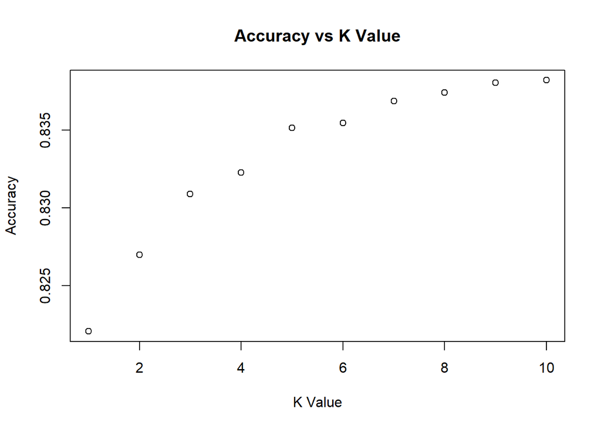

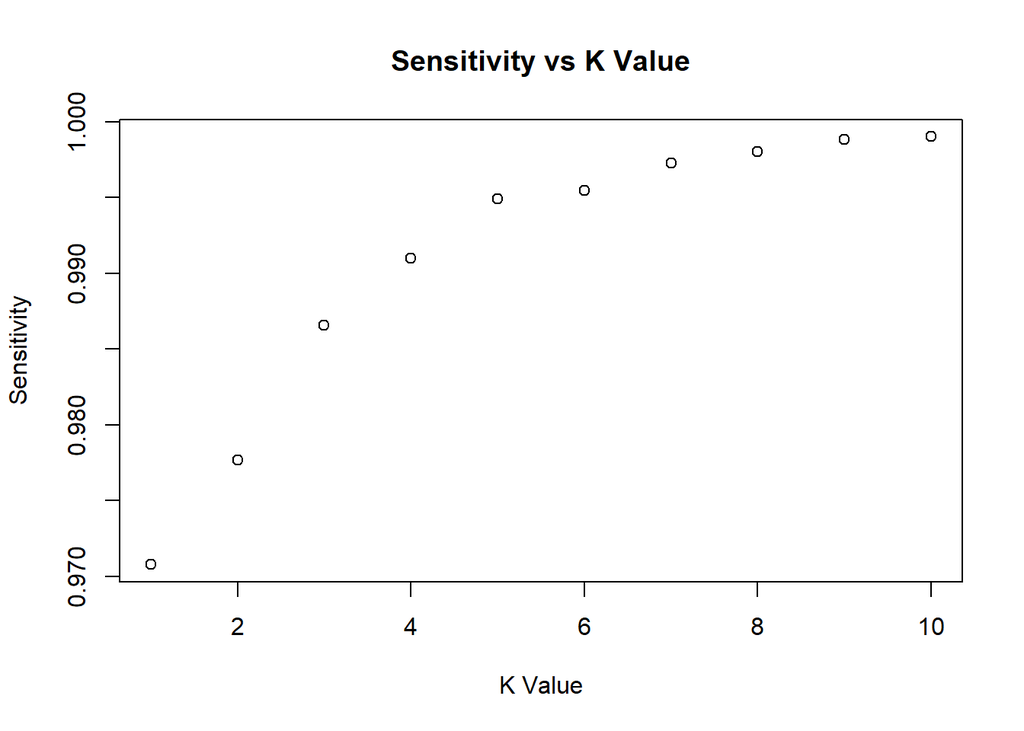

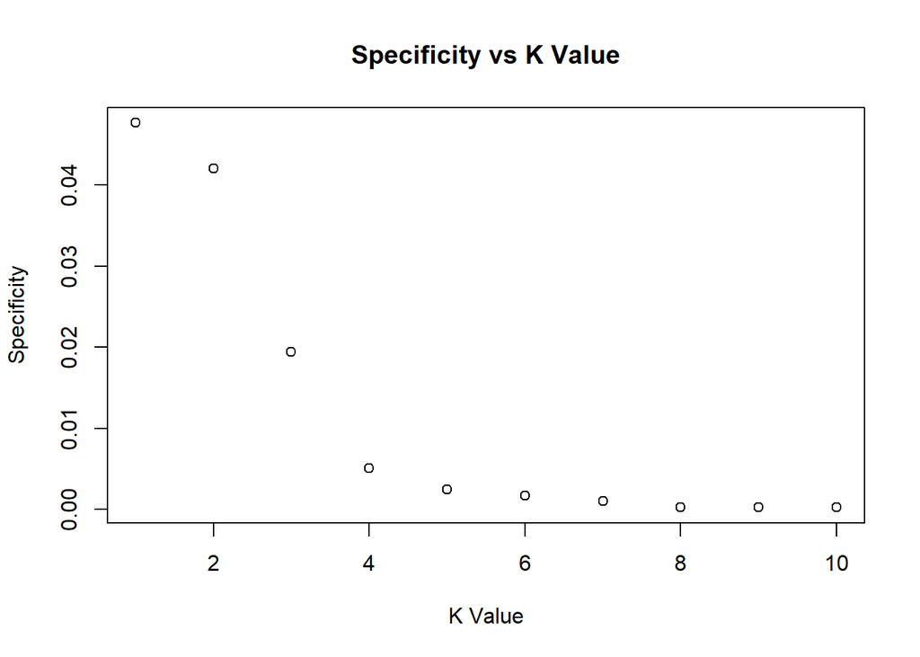

```
## Confusion Matrix and Statistics
##
##
## classifications  No Yes
##             No  222  39
##             Yes   0   0
##
##                Accuracy : 0.8506
##                  95% CI : (0.8014, 0.8915)
##     No Information Rate : 0.8506
##     P-Value [Acc > NIR] : 0.5426
##
##                   Kappa : 0
##
##  Mcnemar's Test P-Value : 1.166e-09
##
##             Sensitivity : 1.0000
##             Specificity : 0.0000
##          Pos Pred Value : 0.8506
##          Neg Pred Value :    NaN
##              Prevalence : 0.8506
##          Detection Rate : 0.8506
##    Detection Prevalence : 1.0000
##       Balanced Accuracy : 0.5000
##
##        'Positive' Class : No
##
```

```
## [1] 10
```

```
## [1] 10
```

```
## [1] 1
```

```
## [1] 0.8381992
```

```
## [1] 0.9990161
```

```
## [1] 0.04764198
```

#Knn.cv test

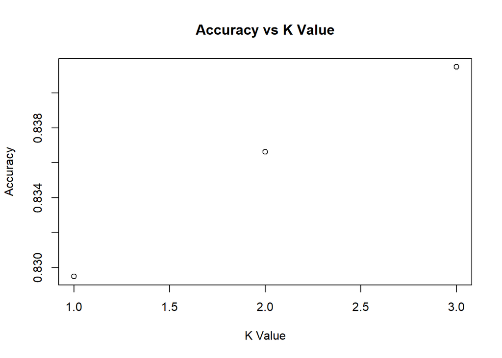

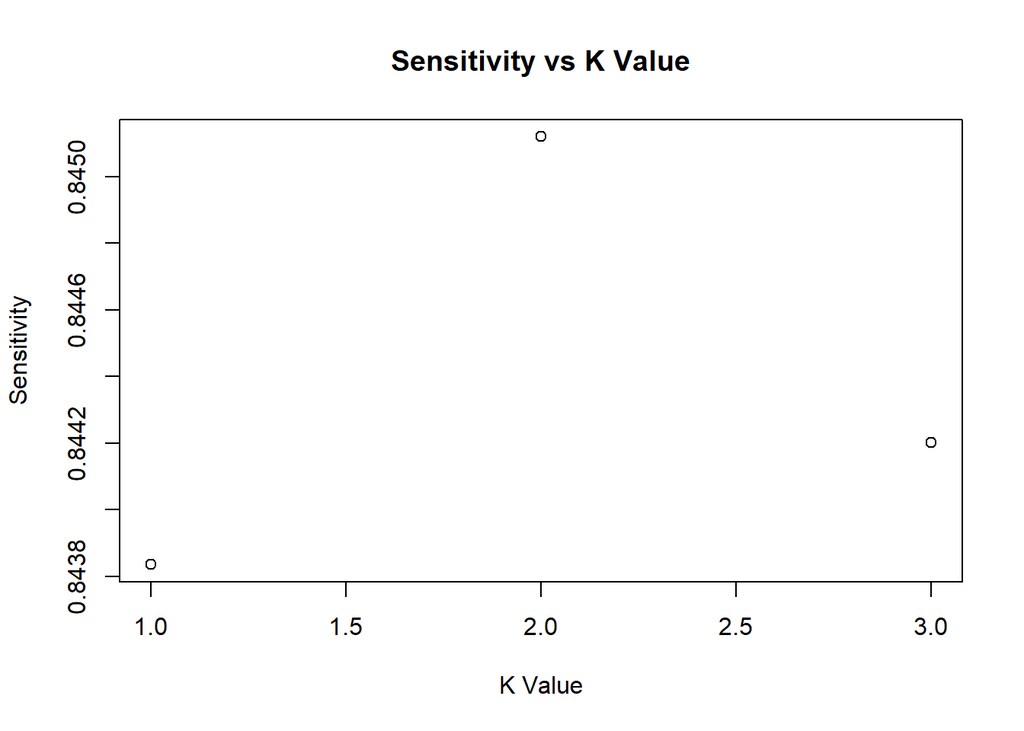

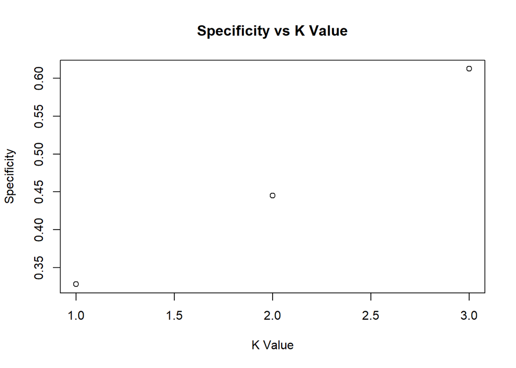

```
## Confusion Matrix and Statistics
##
##
##        No Yes
##   No  726   4
##   Yes 134   6
##
##                Accuracy : 0.8414
##                  95% CI : (0.8154, 0.865)
##     No Information Rate : 0.9885
##     P-Value [Acc > NIR] : 1
##
##                   Kappa : 0.0598
##
##  Mcnemar's Test P-Value : <2e-16
##
##             Sensitivity : 0.84419
##             Specificity : 0.60000
##          Pos Pred Value : 0.99452
##          Neg Pred Value : 0.04286
##              Prevalence : 0.98851
##          Detection Rate : 0.83448
##    Detection Prevalence : 0.83908
##       Balanced Accuracy : 0.72209
##
##        'Positive' Class : No
##
```

```
## [1] 3
```

```
## [1] 2
```

```
## [1] 3
```

```
## [1] 0.8414828
```

```
## [1] 0.8451197
```

```
## [1] 0.6123485
```

#NB test

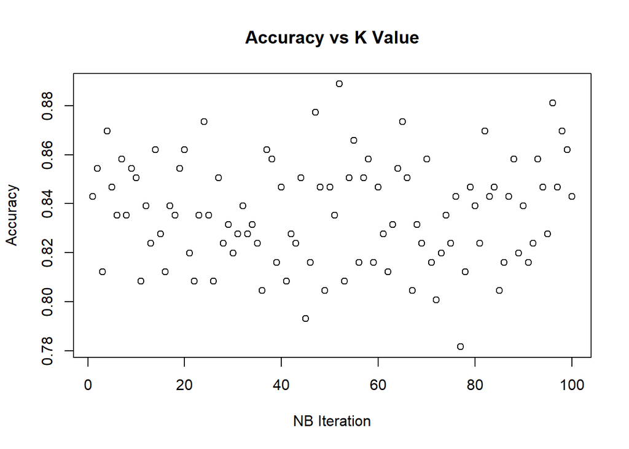